# 11. Reporte avance académico

RA: Valentina Andrade

last update : 23 March,2023

# 1 Objetivo del reporte

El reporte busca analizar el efecto que tiene el desempeño académico (en las pruebas de admisión) sobre la retención (enroll) y el cambio de carrera (switch) de los estudiantes en el primer año, **según su forma de ingreso** (BEA, PACE o regular).

Evidentemente el resultado académico universitario (enroll o switch) depende de características de las carreras (por ejemplo, su dificultad). Es por ello que se controlan los análisis por efectos **efectos fijos** por carrera.

En síntesis, en análisis se basa en

1. Binscatter (gráfico de la derecha): corresponde a la relación bivariada entre el cuantil de desempeño académico en que el está la carrera, y la probabilidad de enroll/switch según la forma de ingreso del estudiante
2. Coefplots (gráfico de la izquierda)[^1]: presenta los coeficientes estimados de un modelo con efecto fijo de carrera. En particular, la variable de interés en la interacción entre ser **elegible** a alguna **politica afirmativa** y el cuantil de de desempeño académico en la carrera que se matriculó por primera vez. Es decir, los coeficientes muestran la diferencia promedio en la probabilidad de estar retenido entre los elegibles PACE y regulares para cada uno de los cuantiles de performance académica de la carrera, controlando por el desempeño del estudiante y el efecto fijo de carrera. De manera simple, esto muestra el resultado académico en el primer año para un estudiante PACE y regular, según si la carrera es “más o menos competitiva/difícil” (según lo que se considere que mide el puntaje promedio ponderado).

Las figuras presentadas son una selección. En la carpeta `04_analysis/figures/combine` podrán encontrar el resto de las figuras. A su vez, la estimación completa de los modelos está en `04_analysis/models`

[^2]: Nota importante: notar coeficiente que está desordenado con un valor de quantil más bajo y aparece su efecto hacia otra dirección. Por problemas con el *reghdfe* se pone como categoría de referencia el 1 solo para una interacción.

# 2 Modelo

## 2.1 Variable dependiente

Sea $i = \lbrace 1,2 \rbrace$ donde $i$ indica el año académico del estudiante, entonces definimos como

- `enroll_{i}` ($Y$): una variable que indica $1$ si el estudiante aparece matriculado al año siguiente y $0$ si no aparece matriculado al año siguiente, independiente de la carrera indicada. Se construye una medida para el sistema centralizado y para todo el sistema (con sufijo `_all` )

Para el calculo de las variables se consideró solo a los estudiantes que estuvieron matriculados en el año de ingreso original (ingreso inmediato).

## 2.2 Variables independientes

- `promlm` ($X$): promedio puntaje lenguaje y matemática en la prueba admisión

En este informe se omite `ptje_pref_sele` debido a que esta variable tiene un rango de valores distintos para elegibles **PACE**. Junto a ello, se pudo constatar una correlación de **0.63** entre el puntaje ponderado de los estudiantes y su promedio lenguaje matemática.

- `codigo_unico_{year}` ($D_1$): código único de carrera (SIES)
- `type`: indica si el estudiante es PACE o Regular. El “ser” depende del modelo. En el caso del *modelo 1* indica **ser elegible** por alguno de esos tipos; en el *modelo 2* haber sido **seleccionado** por esa vía.
- `nq`: quantiles de la distribución del promedio de lenguaje y matemática en la prueba de admisión, por `codigo_unico_{year}`

## 2.3 Modelo

$$Y = X\beta + D_1 \alpha + D_2 \gamma +
\varepsilon$$

- $X$ es **promedio matemáticas y lenguaje** (`promlm`) de la prueba de admisión
  - $X$ de $n \times k$, donde $k=2$
- $D_1$ es **codigo carrera** en el sistema general
  - $D_1$ es de $n \times G_1$, donde $G_1$ es el número de carreras (n grande)
- $D_2$ es la interacción de $type \times nq$
  - $pace$ es dummy donde 1 indica ser *pace* y 0 ser *regular*.
  - $nq$ son 10 quantiles de la distribución de puntaje promedio matemática y lenguaje **por carrera**
  - $D_2$ de $n \times G_2$, donde $G_2$ es el número de combinaciones entre

$$\begin{bmatrix}
\beta & = & (X'X')^{-1}X'(Y - D_1\alpha - D_2
\gamma) \\
\alpha& = & (D_{1}'D_{1}')^{-1}D_1'(Y - X\beta - D_2
\gamma) \\
\gamma & = & D_{2}'D_{2}')^{-1}D_2'(Y - X\beta - D_1
\alpha) \\
\end{bmatrix}$$

# 3 Resultados

El parámetro de interés es $D_2$ pues nos dice el efecto que tiene sobre el mantenerse al primer año en la carrera la **interacción entre la condición de elegibilidad y la calidad de carrera** (medido por el quantil del promedio de las pruebas). Una hipótesis es evidente es que en carreras de “mejor calidad” los estudiantes tendrán más dropout, probablemente a la dificultad de mantenerse en ambientes más competitivos controlando por su propio desempeño en las pruebas.

## 3.1 Según elegibilidad

Como se ve en la **Tabla 1** es interesante es notar que en el último cuantil la diferencia no es estadísticamente significativa. Esto se debe a que probablemente en este segmento de la distirbución los PACE sean los mejores de su cohorte y estén más preparados para enfrentar una carrera más competitiva.

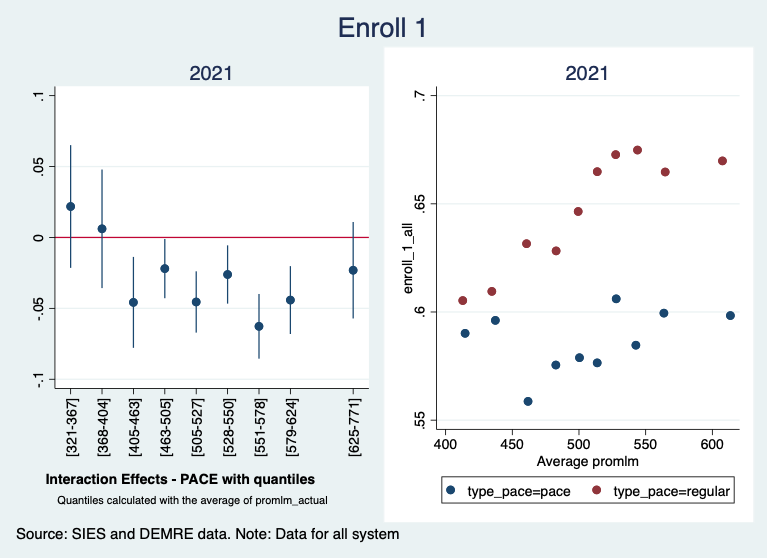

**Figure 1**.

Table 1. enroll_1 by OLS with FE degree-program

| var | coef | stderr | pval | ci-95% |
| --- | --- | --- | --- | --- |
| pace x nq = 1 | -0.0299564 | 0.0129058 | 0.0202820 | 0.005-0.055 |
| pace x nq = 2 | -0.0176793 | 0.0128726 | 0.1696300 | -0.043-0.008 |
| pace x nq = 3 | -0.0368651 | 0.0139228 | 0.0081032 | -0.064–0.01 |
| pace x nq = 4 | -0.0170410 | 0.0137165 | 0.2141037 | -0.044-0.01 |
| pace x nq = 5 | -0.0510978 | 0.0140429 | 0.0002743 | -0.079–0.024 |
| pace x nq = 6 | -0.0676492 | 0.0144545 | 0.0000029 | -0.096–0.039 |
| pace x nq = 7 | -0.0478341 | 0.0154333 | 0.0019400 | -0.078–0.018 |
| pace x nq = 8 | -0.0213800 | 0.0162089 | 0.1871656 | -0.053-0.01 |
| pace x nq = 9 | -0.0378511 | 0.0189514 | 0.0458007 | -0.075–0.001 |
| pace x nq = 10 | -0.0037783 | 0.0227493 | 0.8680919 | -0.048-0.041 |
| promlm | 0.0003486 | 0.0000289 | 0.0000000 | 0-0 |
| _cons | 0.6046999 | 0.0165454 | 0.0000000 | 0.572-0.637 |

Note: $R^2 = 0.269$, $n = 106580$  
Types of students defined by eligibility condition

### 3.1.1 Según cuota ocupada

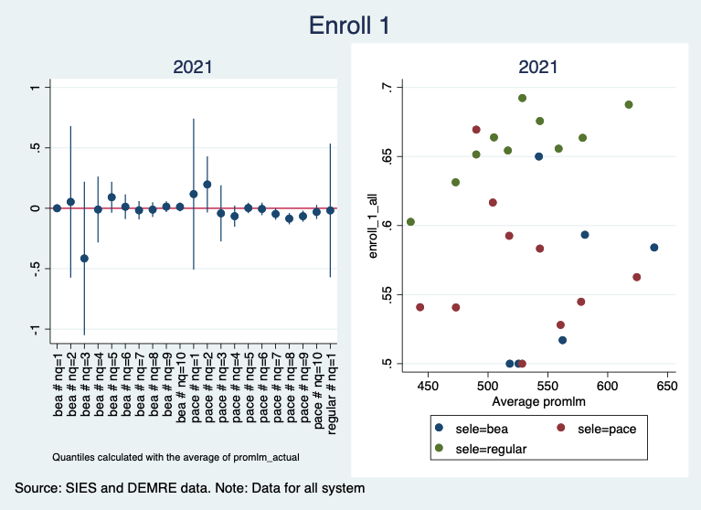

**Figure 2**

Table 2. enroll_1 by OLS with FE degree-program

| var | coef | stderr | pval | ci-95% |
| --- | --- | --- | --- | --- |
| bea x nq = 2 | 0.0531416 | 0.3200476 | 0.8681240 | -0.574-0.68 |
| bea x nq = 3 | -0.4151133 | 0.3240452 | 0.2001864 | -1.05-0.22 |
| bea x nq = 4 | -0.0101820 | 0.1392802 | 0.9417230 | -0.283-0.263 |
| bea x nq = 5 | 0.0912042 | 0.0654375 | 0.1633953 | -0.037-0.219 |
| bea x nq = 6 | 0.0127614 | 0.0521130 | 0.8065504 | -0.089-0.115 |
| bea x nq = 7 | -0.0165935 | 0.0387774 | 0.6687136 | -0.093-0.059 |
| bea x nq = 8 | -0.0110768 | 0.0309518 | 0.7204399 | -0.072-0.05 |
| bea x nq = 9 | 0.0136818 | 0.0228509 | 0.5493462 | -0.031-0.058 |
| bea x nq = 10 | 0.0118823 | 0.0188736 | 0.5289763 | -0.025-0.049 |
| pace x nq = 1 | 0.1174394 | 0.3185718 | 0.7123949 | -0.507-0.742 |
| pace x nq = 2 | 0.1972563 | 0.1185866 | 0.0962388 | -0.035-0.43 |
| pace x nq = 3 | -0.0417741 | 0.1185665 | 0.7245945 | -0.274-0.191 |
| pace x nq = 4 | -0.0652687 | 0.0447755 | 0.1449320 | -0.153-0.022 |
| pace x nq = 5 | 0.0023953 | 0.0222181 | 0.9141476 | -0.041-0.046 |
| pace x nq = 6 | -0.0052916 | 0.0264381 | 0.8413637 | -0.057-0.047 |
| pace x nq = 7 | -0.0470189 | 0.0244423 | 0.0544010 | -0.095-0.001 |
| pace x nq = 8 | -0.0858218 | 0.0240245 | 0.0003542 | -0.133–0.039 |
| pace x nq = 9 | -0.0654613 | 0.0235504 | 0.0054439 | -0.112–0.019 |
| pace x nq = 10 | -0.0304908 | 0.0298747 | 0.3074370 | -0.089-0.028 |
| regular x nq = 1 | -0.0181414 | 0.2822331 | 0.9487490 | -0.571-0.535 |
| promlm | 0.0003665 | 0.0000301 | 0.0000000 | 0-0 |
| _cons | 0.5941899 | 0.0172439 | 0.0000000 | 0.56-0.628 |

Note: $R^2 = 0.279$, $n = 60909$  
Types of students defined by selection condition

Es dificil comparar ambos podemos y pensar en si efectivamente se debe a un problema de variable omitida. Son distintos número de observaciones dado que en el primero están todos los estudiantes mientras que en el segundo solo los del SUA.

### 3.1.2 Otros ejercicios

1. El efecto interacción tiene una forma funcional **convexa**. En la primera parte, los PACE en carreras peores tienen una performance similar a los regulares, en los deciles de al medio su diferencia se hace negativa (peor performance) y luego para carreras buenas vuelve a desaparecer la diferencia entre PACE y regulares.
2. Mirando el binscatter podemos notar que esas diferencias son casi indistingibles en carreras con puntaje promedio lenguaje matemática más bajo
3. Pensé que podría existir algún efecto el tipo de selección que tienen los estudiantes (pensando en los resultados del modelo 2). Por ello incluí como **control** por cuál **vía de acceso fueron seleccionados**. Esos son los coeficientes que aparecen al lado derecho de los *coefplot* y alfinal de las tablas. Como se puede notar el modelo restringido y no restringido son estadísticamente iguales, sumado a que estos controles no son estadísticamente significativos.

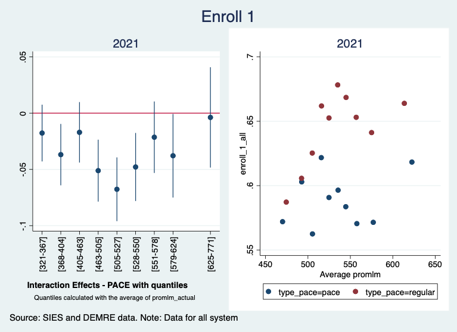

**Figura 3.**

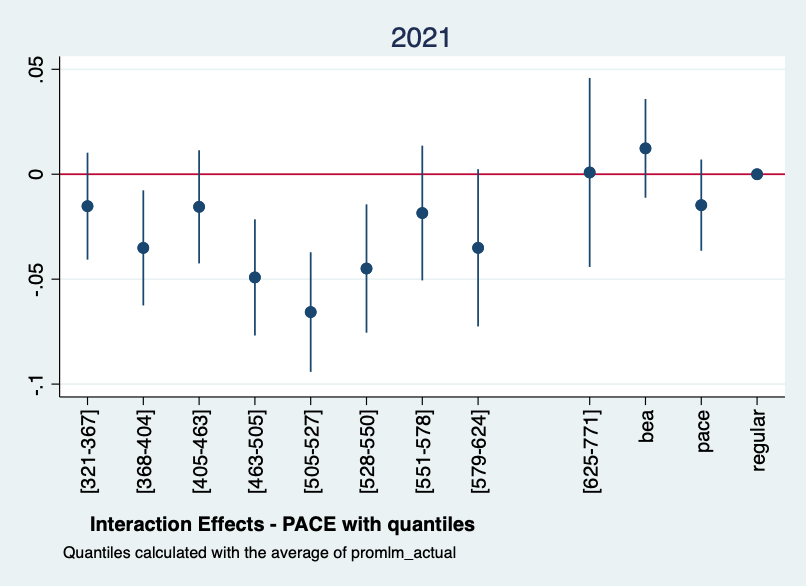

**Figura 4.**

Table 3. enroll_1 by OLS with FE degree-program

| var | Model 3 coef | Model 3 se | Model 3 p | Model 4 coef | Model 4 se | Model 4 p |
| --- | --- | --- | --- | --- | --- | --- |
| pace x nq = 2 | -0.0176793 | 0.0128726 | 0.1696300 | -0.0152184 | 0.0130023 | 0.2418285 |
| pace x nq = 3 | -0.0368651 | 0.0139228 | 0.0081032 | -0.0350972 | 0.0139904 | 0.0121216 |
| pace x nq = 4 | -0.0170410 | 0.0137165 | 0.2141037 | -0.0155296 | 0.0137562 | 0.2589383 |
| pace x nq = 5 | -0.0510978 | 0.0140429 | 0.0002743 | -0.0491671 | 0.0141238 | 0.0004996 |
| pace x nq = 6 | -0.0676492 | 0.0144545 | 0.0000029 | -0.0656782 | 0.0145411 | 0.0000063 |
| pace x nq = 7 | -0.0478341 | 0.0154333 | 0.0019400 | -0.0449226 | 0.0155998 | 0.0039820 |
| pace x nq = 8 | -0.0213800 | 0.0162089 | 0.1871656 | -0.0184824 | 0.0163790 | 0.2591464 |
| pace x nq = 9 | -0.0378511 | 0.0189514 | 0.0458007 | -0.0350698 | 0.0191090 | 0.0664733 |
| pace x nq = 10 | -0.0037783 | 0.0227493 | 0.8680919 | 0.0008457 | 0.0229785 | 0.9706428 |
| pace x nq = 1 | -0.0299564 | 0.0129058 | 0.0202820 | -0.0268247 | 0.0130962 | 0.0405364 |
| promlm | 0.0003486 | 0.0000289 | 0.0000000 | 0.0003426 | 0.0000304 | 0.0000000 |
| _cons | 0.6046999 | 0.0165454 | 0.0000000 | 0.6082714 | 0.0174412 | 0.0000000 |
| bea selection | NA | NA | NA | 0.0123297 | 0.0120012 | 0.3042494 |
| pace selection | NA | NA | NA | -0.0147305 | 0.0110939 | 0.1842478 |

Note: $R^2 = 0.28$, $n = 60.909$  
Types of students defined by eligibility condition